# HW_2 SP2026 ExpDes_StatMod_2

## Question 11: Your Research

## Q11A. Using your model and priors from Homework 1 question 11 where you wrote out a model for your research question, perform a prior predictive simulation of your model.

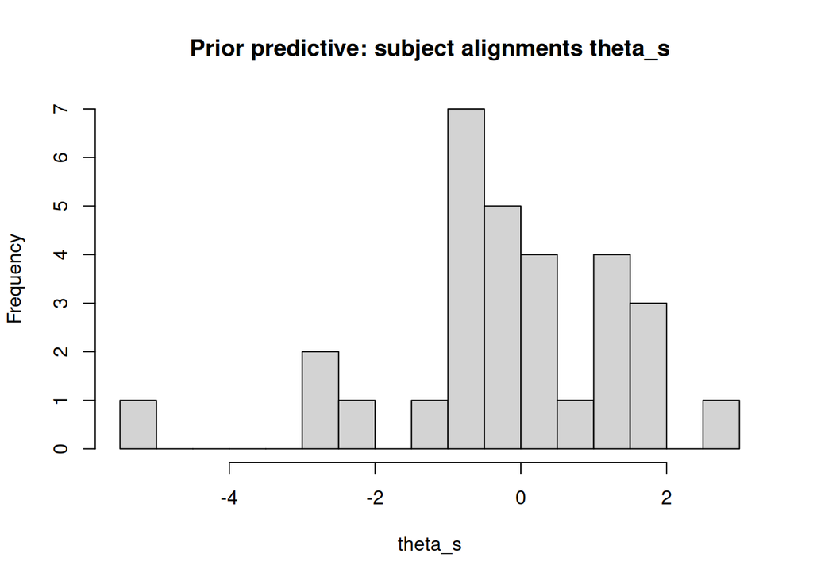

```r
#your prior predictive simulation here

# My modified Gosselin & Schyns style auditory task
# Per subject alignment: theta_s ~ Normal(mu_theta, sigma_theta)
# Group level: mu_theta ~ Normal(0, 1), sigma_theta ~ HalfCauchy(0, 0.5)
# Per-trial response: y_si ~ Bernoulli(inverse_logit(w_s . x_i + b_s))
# I'll simulate what the priors imply for (a) subject alignments and (b) trial response probabilities

set.seed(2026)

# Number of simulated subjects
n_subjects <- 30
n_trials <- 100

# Sample group level priors
mu_theta_samples <- rnorm(n_subjects, 0, 1) # group mean alignment prior

# HalfCauchy isn't in base R, approximate via abs of cauchy
sigma_theta_samples <- abs(rcauchy(n_subjects, 0, 0.5))

# Sample subject level alignment theta_s
theta_s <- rnorm(n_subjects, mu_theta_samples, sigma_theta_samples)

# Look at the distribution of implied alignments
hist(theta_s, breaks=20,
     main="Prior predictive: subject alignments theta_s",
     xlab="theta_s")
```

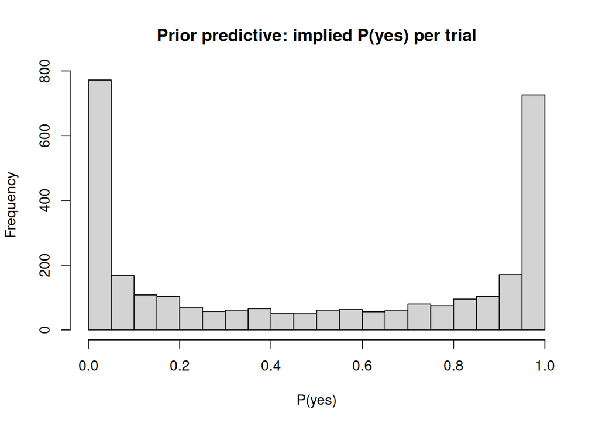

```r
# Now also simulate the trial level logit to see what P(yes) the prior implies
# w_s . x_i is a dot product of K weights and K features
# Assume weights are Normal(0, sd_w) and features are Normal(0, 1)
# Then dot product has std sqrt(K) * sd_w
K <- 20
sd_w <- 1
logit_vals <- rnorm(n_trials * n_subjects, 0, sqrt(K) * sd_w)
probs <- 1 / (1 + exp(-logit_vals))

hist(probs, breaks=30,
     main="Prior predictive: implied P(yes) per trial",
     xlab="P(yes)")
```

## Q11B. Do you like your choice of priors? If not, what would you change?

*Write your answer in the lines below:*

Kind of but not fully. The theta_s (alignment) prior Normal(0, 1) is good and the alignments histogram sit around zero with spread that allows both positive and negative alignment, which is what I want since I don’t want to assume subjects align with the optimal observer. might switch to some thing uniform over (0,1) because we’re working in the realm of angles around a circle so this variable ought to be modular. The interesting or maybe problematic tthing is the trial level: with K = 20 frequency bins and each weight ~ Normal(0,1), the implied dot product has std around sqrt(20) ~ 4.5. That pushes the implied P(yes) distribution toward being bimodal (tons of near 0 and near 1 probabilities), which is maybe not what we’re going for and it says subjects should be almost always extremely confident before they’ve even seen any data (maybe?), which is the opposite of “I have no idea what subjects will do”. I would tighten the per-weight prior to something like Normal(0, 1/sqrt(K)) so that the total dot product has roughly unit variance, which would concentrate the prior P(yes) around 0.5 with reasonable spread. That would encode “I don’t know yet” much better.

## Q11C. Write a causal model for your research question. Think of and discuss what variables you might include in your causal model that would ruin your experiment. This is true of both observational and experimental studies.

*Write your answer in the lines below:*

Causal DAG for the experiment: stimulus_spectrum (x_i) -> subject_response (y_si) subject_weights (w_s) -> subject_response (y_si) alignment theta_s is a derived quantity from w_s vs w_true (not a node necessarily, but computed)

Variables that could be trouble if they act as confounders: - Hearing ability / audiogram. If subjects have different sensitivity across frequencies, what looks like a “weight” on a frequency bin could really be “they can’t hear that frequency well”. Measured audiograms would let me condition on or exclude this. We also running over 2 campuses (Oberlin and Uchicago and oberlin has a conservatory so maybe we can look at their data more closely and we included a thing for listening experience) - Attention / fatigue / time on task. If subjects zone out later in the session their responses become more random, which looks like low theta_s when its really just noise. Randomize trial order and maybe include trial_num as a covariate. We know this one exists. - Adaptation / learning across the session. If subjects change strategy mid-experiment, early-session and late-session responses reflect different w_s. Could split halves and check. Also think it is intuitively likely this is happening

If I don’t handle these I can’t cleanly attribute variation in theta_s to genuine individual differences in decision strategy vs. sensory, task, or motivational confounds.

## Q11D: Please respond to the set of questions that are applicable to your study below, based on whether your study is observational or experimental:

**If your study is an observational study**, what variables would you want to manipulate to de-confound your iv.’s of interest? What are some variables you would not want to include in your multiple regression?

*Write your answer in the lines below:*

**If your study is an experimental study**, and you found related data in an observational study from a larger dataset, how might your i.v.’s now be confounded with other variables? Would it be possible for you to condition on certain variables to de-confound them, or is causal inference not possible for your research question in an observational context (i.e., you would have to run an experiment)?

*Write your answer in the lines below:*

My study is experimental (I present white noise stimuli with controlled spectra, random trial order, and random assignment of stimulus type per trial).

If I found related data in an observational dataset likie maybe recordings of people categorizing naturally occurring sounds then my i.v.’s would be confounded in a bunch of ways. In the observational setting, the spectrum of sounds a person hears is NOT randomly assigned, it correlates with environment (urban vs rural, occupation, indoor vs outdoor), hearing ability (people with hearing loss avoid certain environments oe onl hear certain sounds in an environment), and prior experience (musicians pay attention to certain frequencies). So what looks like a “weight” they put on some frequency is tangled up with what environments they’ve been in and what they already know.

Could I condition my way to causal inference? Partially. If I had enough covariates (audiogram, environment/occupation, musical training, age, hours of task-relevant experience) and the DAG was correct, I could close backdoor paths with multiple regression and at least reduce confounding. But I would always worry about unobserved variables as there’s basically always an attention/motivation/engagement variable I can’t measure observationaly, and that would still bias things.

For the specific question of “what spectral weighting does a subject use when classifying a target/distractor pair that I defined”, causal inference in a purely observational context is not really possible, because the whole concept depends on me as the experimenter defining what the “correct” classification is. Without controlled stimuli and a controlled ground-truth rule there is no w_true to compute alignment against. So I would have to run an experiment at least to establish the reference, even if I then supplement with observational data later.